# Visualización de valores faltantes en 2 variables

En la clase anterior vimos como visualizar datos de una variable para obtener parámetros estadísticos.

En esta clase vamos a abordar el tema de 2 variables cuando contienen valores faltantes.

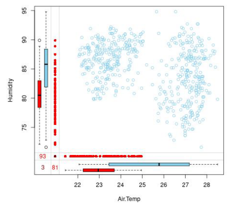

Veamos que tenemos un scatter plot (diagrama de puntos). Los puntos son observaciones (temperatura y humedad). ¿Ahora que pasa con los puntos rojos? significa que tienen mediciones para una variable pero no para la otra. En el caso del eje horizontal x(tenemos medición de temperatura, pero no de humedad), en el caso del eje vertical y (tenemos humedad pero no temperatura).

Lo graficamos de esta manera porque así no interfieren con las mediciones reales que tienen valor. Además podríamos incluir información extra como boxplot para ver la forma que tiene la distribución de cada variable y saber en donde están concentrados.

¿Por qué es importante? Porque cuando realizamos un análisis exploratorio de valores faltantes, queremos saber si estos siguen una relación o una tendencia; por ejemplo una regresión lineal, así llenaremos estos campos utilizando este mismo modelo (es decir el mismo comportamiento de los datos), agrupándolos a su variabilidad.

Entonces este tipo de gráfica nos va ayudar a entender donde se encuentran los valores faltantes en un caso real.

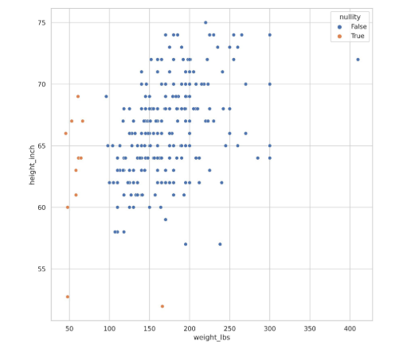

Graficamos y vemos los puntos azules en los cuales nosotros tenemos observaciones para ambas y después los puntos naranjas para los cuales solo tenemos observación de una variable. Así podemos ver el comportamiento para 2 variables.

### Importando librerías

```python
### Importando librerías
import janitor      #Crear pipelines de limpieza de datos
import matplotlib.pyplot as plt
import missingno    #Visualizar valores faltantes
import numpy as np
import pandas as pd
import pyreadr      #Leer archivos adr para este curso
import seaborn as sns
import session_info
import upsetplot    #Para gráfica de relaciones
                    #de nuestros valores faltantes
```

### Configurar el aspecto general de las gráficas del proyecto

```python
%matplotlib inline

sns.set(
    rc={
        "figure.figsize": (10, 10)
    }
)

sns.set_style("whitegrid")
```

### Leer conjunto de datos

```python
#Cargar conjunto de datos
riskfactors = pyreadr.read_r('dataset/riskfactors.rda')

#Convertirlo a Data Frame
riskfactors_df = next(iter(riskfactors.values()))

#Borrar el diccionario
del riskfactors
```

### Importar extensión de Pandas

```python
#Añadir nuestra extensión de Pandas
%run pandas-missing-extension-re2.py
```

### Visualización de valores faltantes para 2 variables

Lo que sucede es que una variable tenía una medición y la otra no, entonces ¿cómo los podemos graficar si no tenemos la medición de otra variable? Nosotros tenemos que agregar un valor `dummy` un valor por defecto que nos permita visualizar en ese momento.

Vamos a crear una función para rellenar con valores `dummies`

`proportion_below` es un porcentaje en el cual nosotros queremos graficar los datos para no mezclarlos con los valores reales. Por eso elegimos una proporción más bajo, debajo del rango de observación de valores reales.

`jitter` son puntos variables y aleatorios que nos ayudan a visualizar nuestros valores en caso de solapamiento.

`seed` debido a que introducimos un componente aleatorio, también necesitamos este parámetro que llamamos *semilla* y lo definimos como como 42 porque es un número simbólico.

Lo que nos regresa la función es una serie.

Queremos graficar por debajo de nuestro rango de variables para que no se traslapen.

```
column_shifted = column.min() - column.min()*proportion_below
```

Esta instrucción es para ajustar nuestros datos en una zona donde no interfiera con nuestros datos reales.

```python
def column_fill_with_dummies(
        column:pd.Series, # o puede ser string
        proportion_below: float = 0.10,
        jitter: float = 0.75,
        seed: int=42
) -> pd.Series:
    #¿Que hará nuestra función
    #copia para evitar modificar datos reales
    column = column.copy(deep=True)
    # Extraer valores
    missing_mask = column.isna()
    # Conteo de valores faltantes
    number_missing_values = missing_mask.sum()
    # Rango de nuestras variables
    column_range = column.max() - column.min()

    #Hacer shift a nuestros datos
    #Shift data
    column_shifted = column.min() - column.min()*proportion_below

    #Crear ruido para diferenciar el solapamiento
    #Add jitter around the points
    np.random.seed(seed)

    #Columna con ruido
    column_jitter = (np.random.rand(number_missing_values)-2)*column_range*jitter

    #Guardar conjunto de datos
    #Dummy data
    column[missing_mask] = column_shifted + column_jitter

    return column
```

Hemos completado la función que nos permitirá crear nuestra gráfica en scatterplot, de una manera sencilla. Vayamos a la siguiente clase para aprender a hacerlo.